# sgdm: an R package for performing sparse generalized dissimilarity modeling including tools for gdm

Pedro J. Leitão, Marcel Schwieder, Cornelius Senf

2016-08-11

## Installing `sgdm`

In order to install `sgdm` from GitHub, you need to install the `devtools` package first. Using the `install_git` function in the `dectools` package, the `sgdm` package can be easily installed:

```r
library(devtools)
devtools::install_git("sparsegdm/sgdm_package")
library(sgdm)
```

## Running a `sgdm` model

- Parameterize and train the SGDM model
- Reduce the SGDM model by identifying non-significant predictors
- Validate the SGDM model
- Map community composition patterns

In the following we will go through each of the four steps in order to examplify how the `sgdm` package works.

### Parameterize and train the SGDM model

For parameterizing a `sgdm` model, it is necessary to identify the best penalization parameter pair using a heuristic grid search implemented in the function `sgdm.param`:

```r
sgdm.gs <- sgdm.param(predData = spectra, bioData = trees, k = 30, predPenalization = seq(0.6, 1, 0.1), bioPenalization = seq(0.6, 1, 0.1), geo = F)
```

The parameter `k` sets the number of components to be used and the parameters `predPenalization` and `bioPenalization` set the penalization values to be tested (ranging from 0 (strong penalization) to 1 (weak penalization). The standard values implemented in this function range from 0.6 to 1 in 0.1 steps, but these values can be manually configured to better match the used datasets. Finally, the user can specify if geographical distance as a variable in the GDM model should be used. Note that this function implementation only allows biological data in **format 1** specification as described in the `gdm` package.

The function `sgdm.param` returns a performance matrix, with the performance values (RMSE) of each parameter pair estimated from 5-fold cross-validation:

```r
print(sgdm.gs, digits = 4)
```

```
##        0.6    0.7    0.8    0.9      1
## 0.6 0.1210 0.1221 0.1191 0.1280 0.1361
## 0.7 0.1217 0.1054 0.1290 0.1373 0.1253
## 0.8 0.1222 0.1288 0.1262 0.1280 0.1227
## 0.9 0.1283 0.1228 0.1267 0.1377 0.1385
## 1   0.1255 0.1227 0.1267 0.1406 0.1402
```

Using the performance matrix and the `sgdm.best` function, we can retreive the best model (`output = "m"`):

```r
sgdm.model <- sgdm.best(perf.matrix = sgdm.gs, predData = spectra, bioData = trees, output = "m", k = 30)
```

Summary of the model:

```r
summary(sgdm.model)
```

```
## [1]
## [1]
## [1] GDM Modelling Summary
## [1] Creation Date:  Thu Aug 11 08:55:44 2016
## [1]
## [1] Name:  sgdm.model
## [1]
## [1] Data:  spData
## [1]
## [1] Samples:  435
## [1]
## [1] Geographical distance used in model fitting?  FALSE
## [1]
## [1] NULL Deviance:  80.3619323765005
## [1] GDM Deviance:  21.4058863939293
```

[output cut: 274 more lines]

```r
sgdm.model$explained
```

```
## [1] 73.36315
```

Alternatively, the sgdm.best function also allows the user to retrieve the resulting sparse canonical components (`output = "c"`) or the respective canonical vectors (`output = "v"`).

```r
sgdm.sccbest <- sgdm.best(perf.matrix = sgdm.gs, predData = spectra, bioData = trees, output = "c", k = 30)
sgdm.vbest <- sgdm.best(perf.matrix = sgdm.gs, predData = spectra, bioData = trees, output = "v", k = 30)
```

### Reduce the SGDM model by removing non-significant predictors

Some of the sparse canonical components might be less important than others. In order to reduce the model complexity, we can utilize the `gdm.varsig` function with the sparse canonical components and the biological data:

```r
sigtest.sgdm <- gdm.varsig(predData = sgdm.sccbest, bioData = trees)
```

and use this significance test result to reduce the predictor data for re-training the model:

```r
sgdm.sccbest.red <- data.reduce(data = sgdm.sccbest, datatype = "pred", sigtest = sigtest.sgdm)
```

```
## Reducing environmental dataset following significance test result
##
## Data reduction finished
```

In order to train the final model, the significant sparse canonical components must be combined with the biological dataset in a site pair dataset using the function `formatsitepair` in the `gdm` package:

```r
spData.sccabest.red <- gdm::formatsitepair(bioData = trees, bioFormat = 1, dist = "bray",
                                           abundance = TRUE, siteColumn = "Plot_ID",
                                           XColumn = "X",YColumn = "Y", predData = sgdm.sccbest.red)

sgdm.model.red <- gdm::gdm(data = spData.sccabest.red)
```

The final model can now be inspected and the predicted dissimilarities plotted:

```r
summary(sgdm.model.red)
```

```
## [1]
## [1]
## [1] GDM Modelling Summary
## [1] Creation Date:  Thu Aug 11 08:58:11 2016
## [1]
## [1] Name:  sgdm.model.red
## [1]
## [1] Data:  spData.sccabest.red
## [1]
## [1] Samples:  435
## [1]
## [1] Geographical distance used in model fitting?  FALSE
## [1]
## [1] NULL Deviance:  80.3619323765005
## [1] GDM Deviance:  24.03476135259
```

[output cut: 139 more lines]

```r
sgdm.model.red$explained
```

```
## [1] 70.09186
```

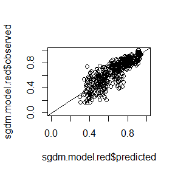

```r
plot(sgdm.model.red$predicted, sgdm.model.red$observed, xlim = c(0, 1), ylim = c(0, 1))
abline(0, 1)
```

### Validate the SGDM model

For independent validation, there is a function in the `sgdm` package called `gdm.cv`, which performes n-fold cross-validation on a (S)GDM model:

```r
gdm.cv(spData = spData.sccabest.red, nfolds = 10)
```

```
##
## GDM model cross-validation
##
## Performing 10-fold cross-validation
##
## Fold 1 of 10
## Fold 2 of 10
## Fold 3 of 10
## Fold 4 of 10
## Fold 5 of 10
## Fold 6 of 10
## Fold 7 of 10
## Fold 8 of 10
## Fold 9 of 10
## Fold 10 of 10
##
## Calculating model Root Mean Square Error (RMSE)...
##
## Model performance calculated
```

```
## [1] 0.1184957
```

The functions returns the cross-validated RMSE value (default). Alternatively, the cross-validated coefficient of determination (r$^2$) can be returned:

```r
gdm.cv(spData = spData.sccabest.red, nfolds = 10, performance = "r2")
```

```
##
## GDM model cross-validation
##
## Performing 10-fold cross-validation
##
## Fold 1 of 10
## Fold 2 of 10
## Fold 3 of 10
## Fold 4 of 10
## Fold 5 of 10
## Fold 6 of 10
## Fold 7 of 10
## Fold 8 of 10
## Fold 9 of 10
## Fold 10 of 10
##
## Calculating model R-square (R2)...
##
## Model performance calculated
```

```
## [1] 64.65879
```

### Map community composition patterns

The community composition patterns can be plotted along the main axes of variation following an NMDS transformation of the predicted dissimilarities between sample pairs:

```r
community.samples <- gdm.map(spData = spData.sccabest.red, model = sgdm.model.red, k = 0, t = 0.1)
```

```
##
## Performing GDM mapping
##
##
## Derive number of NMDS components based on stress values below 0.1
##
## Mean stress value after 20 iterations with k = 1 is 0.5477463
##
## Mean stress value after 20 iterations with k = 2 is 0.3265804
##
## Mean stress value after 20 iterations with k = 3 is 0.2362171
##
## Mean stress value after 20 iterations with k = 4 is 0.1824501
##
## Mean stress value after 20 iterations with k = 5 is 0.1515334
##
## Mean stress value after 20 iterations with k = 6 is 0.1256732
##
## Mean stress value after 20 iterations with k = 7 is 0.106608
##
## Mean stress value after 20 iterations with k = 8 is 0.09169259
##
## Mean stress value after 20 iterations with k = 9 is 0.07944123
##
## Mean stress value after 20 iterations with k = 10 is 0.06957175
##
## Mean stress value after 20 iterations with k = 11 is 0.06049288
##
## Mean stress value after 20 iterations with k = 12 is 0.05284233
##
## Mean stress value after 20 iterations with k = 13 is 0.04635562
##
## Mean stress value after 20 iterations with k = 14 is 0.04088689
##
## Mean stress value after 20 iterations with k = 15 is 0.03599491
##
## Mean stress value after 20 iterations with k = 16 is 0.03158013
##
## Mean stress value after 20 iterations with k = 17 is 0.02706971
##
```

[output cut: 16 more lines]

```
## Mean stress value after 20 iterations with k = 26 is 0.0002165681
##
## Mean stress value after 20 iterations with k = 27 is 0.0001031877
##
## Mean stress value after 20 iterations with k = 28 is 9.788295e-05
##
## Mean stress value after 20 iterations with k = 29 is 9.414289e-05
##
## Mean stress value after 20 iterations with k = 30 is 9.369149e-05
##
##
## Performing NMDS transformation on sample pair sites with 8 components
##
##
## NMDS stress value: 0.09191125
```

The number of NMDS axes to be extracted is by default automatically determined by the resulting mean NMDS stress values out of 20 iterations following:

- < 0.05 excellent
- < 0.1 good
- > 0.1 poor

The number of NMDS axes (`k`) can also be set by the user.

These patterns can also be mapped in space using a predictor map. As it would be unfeasible to run a NMDS on the dissimilarities between all possible pairs of image pixels, it is possible to assign the pixels to the NMDS axes from the sample pairs, through knn-imputation.

The predictor map used here is called `spectral.image` and is a `RasterStack` object, which can be plotted in false color:

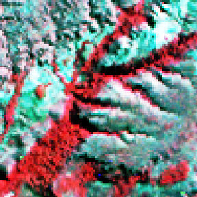

```r
raster::plotRGB(spectral.image, r = 43, g = 22, b = 12, stretch = "hist")
```

In order to map the community composition patterns predicted by sgdm, it is necessary to apply the canonical transformation onto the prediction map. The resulting component map must also to be reduced according to the variable significance test:

```r
component.image <- predData.transform(predData = spectral.image, v = sgdm.vbest)
```

```
##
## predData is data type  RasterStack
```

```r
component.image.red <- data.reduce(component.image, datatype = "pred", sigtest = sigtest.sgdm)
```

```
## Reducing environmental dataset following significance test result
##
##
## Input data is type  RasterStack
##
## Data reduction finished
```

With the resulting reduced component image, it is possible to map the community composition patterns in space. For example, in order to visualize them in RGB space, it is possible to extract 3 NMDS axes:

```r
map.sgdm.red <- gdm.map(spData = spData.sccabest.red, predMap = component.image.red, model = sgdm.model.red, k = 3)
```

```
##
## Performing GDM mapping
##
##
## Performing NMDS transformation on sample pair sites with 3 components
##
##
## NMDS stress value: 0.2308076
##
## predMap, is data type RasterStack and will be used to impute the NMDS-transformed GDM predicted dissimilarities
```

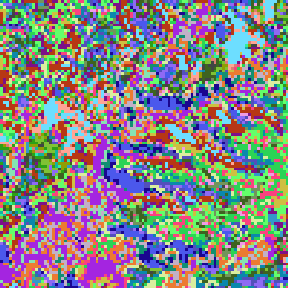

```r
raster::plotRGB(map.sgdm.red, r = 3, g = 2, b = 1, stretch = "hist")
```